# Final project-checkpoint

#### Student Exam Performance Dataset Analysis

##### This project is to analyse how the various student-related academic, lifestyle, and socio-enconmic factores influence the exam perdormance and identify the patterns and relationships between these factors and the student's score.The dataset include study hours,student attendence,sleep hours,motivation,tutoring sessions,parental involvement,school type and other envirmental features.The main target varibale is Exam_Score which represents the student final exam score.

```python
#importing libraries
import numpy as np
import pandas as pd
import matplotlib.pyplot as plt
import seaborn as sns
#Setting the background style of the plot
sns.set_style("whitegrid")
```

```python
#Loading dataset
df=pd.read_csv(r"C:\Users\anuro\OneDrive\Desktop\DATA ANALYTICS\.ipynb_checkpoints\.ipynb_checkpoints\StudentPerformanceFactors.csv")
#To start index from 1
df.index=df.index+1
#To show first few rows of the DataFrame
df.head()
```

|  | Hours_Studied | Attendance | Parental_Involvement | Access_to_Resources | Extracurricular_Activities | Sleep_Hours | Previous_Scores | Motivation_Level | Internet_Access | Tutoring_Sessions | Family_Income | Teacher_Quality | School_Type | Peer_Influence | Physical_Activity | Learning_Disabilities | Parental_Education_Level | Distance_from_Home | Gender | Exam_Score |
| --- | --- | --- | --- | --- | --- | --- | --- | --- | --- | --- | --- | --- | --- | --- | --- | --- | --- | --- | --- | --- |
| 1 | 23 | 84 | Low | High | No | 7 | 73 | Low | Yes | 0 | Low | Medium | Public | Positive | 3 | No | High School | Near | Male | 67 |
| 2 | 19 | 64 | Low | Medium | No | 8 | 59 | Low | Yes | 2 | Medium | Medium | Public | Negative | 4 | No | College | Moderate | Female | 61 |
| 3 | 24 | 98 | Medium | Medium | Yes | 7 | 91 | Medium | Yes | 2 | Medium | Medium | Public | Neutral | 4 | No | Postgraduate | Near | Male | 74 |
| 4 | 29 | 89 | Low | Medium | Yes | 8 | 98 | Medium | Yes | 1 | Medium | Medium | Public | Negative | 4 | No | High School | Moderate | Male | 71 |
| 5 | 19 | 92 | Medium | Medium | Yes | 6 | 65 | Medium | Yes | 3 | Medium | High | Public | Neutral | 4 | No | College | Near | Female | 70 |

```python
#Summary of the DataFrame-
df.info()
```

```
<class 'pandas.core.frame.DataFrame'>
RangeIndex: 6607 entries, 1 to 6607
Data columns (total 20 columns):
 #   Column                      Non-Null Count  Dtype
---  ------                      --------------  -----
 0   Hours_Studied               6607 non-null   int64
 1   Attendance                  6607 non-null   int64
 2   Parental_Involvement        6607 non-null   object
 3   Access_to_Resources         6607 non-null   object
 4   Extracurricular_Activities  6607 non-null   object
 5   Sleep_Hours                 6607 non-null   int64
 6   Previous_Scores             6607 non-null   int64
 7   Motivation_Level            6607 non-null   object
 8   Internet_Access             6607 non-null   object
 9   Tutoring_Sessions           6607 non-null   int64
 10  Family_Income               6607 non-null   object
 11  Teacher_Quality             6529 non-null   object
 12  School_Type                 6607 non-null   object
 13  Peer_Influence              6607 non-null   object
 14  Physical_Activity           6607 non-null   int64
 15  Learning_Disabilities       6607 non-null   object
 16  Parental_Education_Level    6517 non-null   object
 17  Distance_from_Home          6540 non-null   object
 18  Gender                      6607 non-null   object
 19  Exam_Score                  6607 non-null   int64
dtypes: int64(7), object(13)
memory usage: 1.0+ MB
```

##### The attributes to be analysed are Hours_Studied, Attendance,Parental_Involvement,Access_to_Resources, Extracurricular_Activities, Sleep_Hours,Previous_Scores,Motivation_Level,Internet_Access,Tutoring_Sessions,Family_Income,Teacher_Quality, School_Type,Peer_Influence,Physical_Activity, Learning_Disabilities,Parental_Education_Level,Distance_from_Home,Gender and Exam_Score

```python
#To get statistical summary of numerical columns
df.describe()
```

|  | Hours_Studied | Attendance | Sleep_Hours | Previous_Scores | Tutoring_Sessions | Physical_Activity | Exam_Score |
| --- | --- | --- | --- | --- | --- | --- | --- |
| count | 6607.000000 | 6607.000000 | 6607.00000 | 6607.000000 | 6607.000000 | 6607.000000 | 6607.000000 |
| mean | 19.975329 | 79.977448 | 7.02906 | 75.070531 | 1.493719 | 2.967610 | 67.235659 |
| std | 5.990594 | 11.547475 | 1.46812 | 14.399784 | 1.230570 | 1.031231 | 3.890456 |
| min | 1.000000 | 60.000000 | 4.00000 | 50.000000 | 0.000000 | 0.000000 | 55.000000 |
| 25% | 16.000000 | 70.000000 | 6.00000 | 63.000000 | 1.000000 | 2.000000 | 65.000000 |
| 50% | 20.000000 | 80.000000 | 7.00000 | 75.000000 | 1.000000 | 3.000000 | 67.000000 |
| 75% | 24.000000 | 90.000000 | 8.00000 | 88.000000 | 2.000000 | 4.000000 | 69.000000 |
| max | 44.000000 | 100.000000 | 10.00000 | 100.000000 | 8.000000 | 6.000000 | 101.000000 |

```python
#To get the dimension of the DataFrame
df.shape
```

```
(6607, 20)
```

```python
# Finding total number of missing values in each column
df.isnull().sum()
```

```
Hours_Studied                  0
Attendance                     0
Parental_Involvement           0
Access_to_Resources            0
Extracurricular_Activities     0
Sleep_Hours                    0
Previous_Scores                0
Motivation_Level               0
Internet_Access                0
Tutoring_Sessions              0
Family_Income                  0
Teacher_Quality               78
School_Type                    0
Peer_Influence                 0
Physical_Activity              0
Learning_Disabilities          0
Parental_Education_Level      90
Distance_from_Home            67
Gender                         0
Exam_Score                     0
dtype: int64
```

```python
#Finding duplicated rows
df.duplicated().sum()
```

```
np.int64(0)
```

```python
#To show the column name
df.columns
```

```
Index(['Hours_Studied', 'Attendance', 'Parental_Involvement',
       'Access_to_Resources', 'Extracurricular_Activities', 'Sleep_Hours',
       'Previous_Scores', 'Motivation_Level', 'Internet_Access',
       'Tutoring_Sessions', 'Family_Income', 'Teacher_Quality', 'School_Type',
       'Peer_Influence', 'Physical_Activity', 'Learning_Disabilities',
       'Parental_Education_Level', 'Distance_from_Home', 'Gender',
       'Exam_Score'],
      dtype='object')
```

```python
#Handling missing values
#Since it is a categorical column,selecting the top most common value to fill null values
df["Teacher_Quality"]=df["Teacher_Quality"].fillna(df["Teacher_Quality"].mode()[0])
```

```python
#Since it is a categorical column,selecting the top most common value to fill null values
df["Parental_Education_Level"]=df["Parental_Education_Level"].fillna(df["Parental_Education_Level"].mode()[0])
```

```python
#Since it is a categorical column,selecting the top most common value to fill null values
df["Distance_from_Home"]=df["Distance_from_Home"].fillna(df["Distance_from_Home"].mode()[0])
```

```python
#Checking
df.isnull().sum()
```

```
Hours_Studied                 0
Attendance                    0
Parental_Involvement          0
Access_to_Resources           0
Extracurricular_Activities    0
Sleep_Hours                   0
Previous_Scores               0
Motivation_Level              0
Internet_Access               0
Tutoring_Sessions             0
Family_Income                 0
Teacher_Quality               0
School_Type                   0
Peer_Influence                0
Physical_Activity             0
Learning_Disabilities         0
Parental_Education_Level      0
Distance_from_Home            0
Gender                        0
Exam_Score                    0
dtype: int64
```

```python
#Finding datatypes of each column
df.dtypes
```

```
Hours_Studied                  int64
Attendance                     int64
Parental_Involvement          object
Access_to_Resources           object
Extracurricular_Activities    object
Sleep_Hours                    int64
Previous_Scores                int64
Motivation_Level              object
Internet_Access               object
Tutoring_Sessions              int64
Family_Income                 object
Teacher_Quality               object
School_Type                   object
Peer_Influence                object
Physical_Activity              int64
Learning_Disabilities         object
Parental_Education_Level      object
Distance_from_Home            object
Gender                        object
Exam_Score                     int64
dtype: object
```

```python
#Formatting
#creating a list of categorical columns and changing the datatype as category
categorical_cols=["Parental_Involvement","Access_to_Resources","Extracurricular_Activities","Motivation_Level","Internet_Access","Family_Income","Teacher_Quality","School_Type","Peer_Influence","Learning_Disabilities","Parental_Education_Level","Distance_from_Home","Gender"]
for col in categorical_cols:
    df[col]=df[col].astype("category")
```

```python
#Checking the datatypes
df.dtypes
```

```
Hours_Studied                    int64
Attendance                       int64
Parental_Involvement          category
Access_to_Resources           category
Extracurricular_Activities    category
Sleep_Hours                      int64
Previous_Scores                  int64
Motivation_Level              category
Internet_Access               category
Tutoring_Sessions                int64
Family_Income                 category
Teacher_Quality               category
School_Type                   category
Peer_Influence                category
Physical_Activity                int64
Learning_Disabilities         category
Parental_Education_Level      category
Distance_from_Home            category
Gender                        category
Exam_Score                       int64
dtype: object
```

```python
#finding and Removing the outliers
print("Maximum Exam score:",max(df["Exam_Score"]))
```

```
Maximum Exam score: 101
```

```python
#row with outlier
df[df["Exam_Score"]>100]
```

|  | Hours_Studied | Attendance | Parental_Involvement | Access_to_Resources | Extracurricular_Activities | Sleep_Hours | Previous_Scores | Motivation_Level | Internet_Access | Tutoring_Sessions | Family_Income | Teacher_Quality | School_Type | Peer_Influence | Physical_Activity | Learning_Disabilities | Parental_Education_Level | Distance_from_Home | Gender | Exam_Score |
| --- | --- | --- | --- | --- | --- | --- | --- | --- | --- | --- | --- | --- | --- | --- | --- | --- | --- | --- | --- | --- |
| 1526 | 27 | 98 | Low | Medium | Yes | 6 | 93 | Low | No | 5 | High | High | Public | Positive | 3 | No | High School | Moderate | Female | 101 |

```python
#Removing the outlier from the DataFrame
df=df[df["Exam_Score"]<=100]
```

```python
#Checking
print("Maximum Exam score:",max(df["Exam_Score"]))
```

```
Maximum Exam score: 100
```

```python
print("Minimum Exam score:",min(df["Exam_Score"]))
```

```
Minimum Exam score: 55
```

```python
#Creating a dataframe named summary to check the maximum and minimum values of numerical values.
Numerical_cols=["Hours_Studied","Attendance","Sleep_Hours","Previous_Scores","Tutoring_Sessions","Physical_Activity","Exam_Score"]
summary=pd.DataFrame({"Maximum":df[Numerical_cols].max(),"Minimum":df[Numerical_cols].min()})
summary
```

|  | Maximum | Minimum |
| --- | --- | --- |
| Hours_Studied | 44 | 1 |
| Attendance | 100 | 60 |
| Sleep_Hours | 10 | 4 |
| Previous_Scores | 100 | 50 |
| Tutoring_Sessions | 8 | 0 |
| Physical_Activity | 6 | 0 |
| Exam_Score | 100 | 55 |

```python
#Derived features
#Adding a new column to the DataFrame
df["Average_score"]=(df["Previous_Scores"]+df["Exam_Score"])/2
```

```python
#Assigning grades by using function
def assign_grade(score) :
    if score>=90:
        return "A"
    elif score>=75:
        return "B"
    elif score>=60:
        return "c"
    elif score>=45:
        return "D"
    else :
        return "E"
df["Grade"]=df["Exam_Score"].apply(assign_grade)
```

```python
#Transformation- Normalizing Attendance
df["Attendance_norm"]=((df["Attendance"])-df["Attendance"].min())/(df["Attendance"].max()-df["Attendance"].min())
df["Attendance_norm"]=df["Attendance_norm"].round(1)
df["Attendance_norm"]
```

```
1       0.6
2       0.1
3       1.0
4       0.7
5       0.8
       ...
6603    0.2
6604    0.4
6605    0.8
6606    0.6
6607    0.2
Name: Attendance_norm, Length: 6606, dtype: float64
```

##### EDA & Visualizations

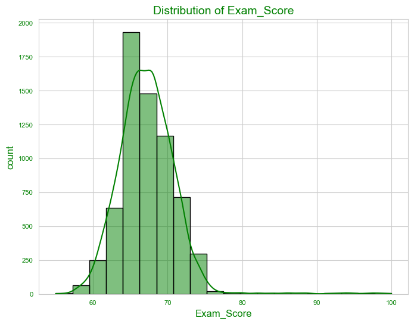

```python
#Visualization 1
#univariate analysis
#To change the figure size
plt.figure(figsize=(8,6))
#creating histogram with green bars
sns.histplot(df["Exam_Score"],bins=20,kde=True,color="green",edgecolor="black")
#Giving title of the plot
plt.title("Distribution of Exam_Score",color="green",fontsize=14)
#Giving x label and y label
plt.xlabel("Exam_Score",color="green",fontsize=12)
plt.ylabel("count",color="green",fontsize=12)
#Giving color and fontsize to xticks and yticks
plt.xticks(color="green",fontsize=8)
plt.yticks(color="green",fontsize=8)
#To show the plot
plt.show()
```

The Histogram - Distribution of Exam_score portraits that most students scored in between 60 and 70

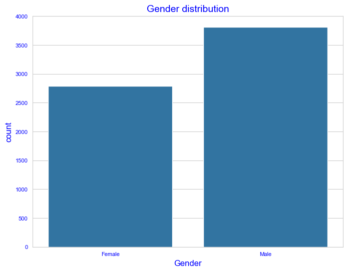

```python
#Visualization 2
#Gender distribution
plt.figure(figsize=(8,6))
sns.countplot(x="Gender",data=df)
plt.title("Gender distribution",color="blue",fontsize=14)
plt.xlabel("Gender",color="blue",fontsize=12)
plt.ylabel("count",color="blue",fontsize=12)
plt.xticks(color="blue",fontsize=8)
plt.yticks(color="blue",fontsize=8)
plt.show()
```

The countplot shows that male students are more numerous than females students

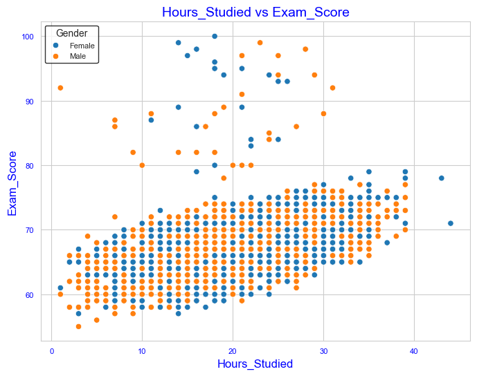

```python
#Visualization 3
#Bivariate analysis
#Scatter plot
plt.figure(figsize=(8,6))
sns.scatterplot(x="Hours_Studied",y="Exam_Score",data=df,hue="Gender")
plt.title("Hours_Studied vs Exam_Score",color="blue",fontsize=14)
plt.xlabel("Hours_Studied",color="blue",fontsize=12)
plt.ylabel("Exam_Score",color="blue",fontsize=12)
plt.xticks(color="blue",fontsize=8)
plt.yticks(color="blue",fontsize=8)
plt.legend(title="Gender",title_fontsize=10, fontsize=8,loc="upper left",frameon=True,edgecolor="black")
plt.show()
```

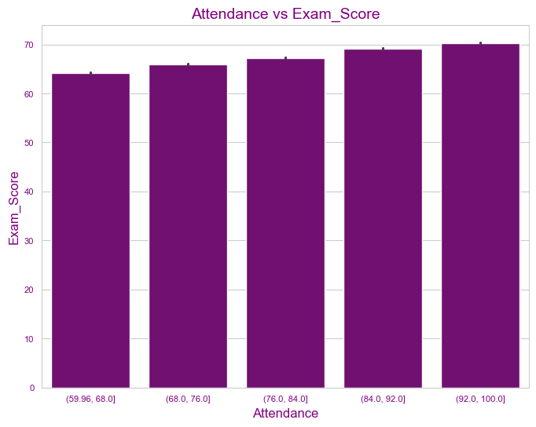

```python
#Visualization 4
#Barplot
#creating a new column and dividing the attendence into intervals
df["Attendance_bin"]=pd.cut(df["Attendance"],bins=5)
plt.figure(figsize=(8,6))
sns.barplot(x="Attendance_bin",y="Exam_Score",data=df,color="purple")
plt.title("Attendance vs Exam_Score",color="purple",fontsize=14)
plt.xlabel("Attendance",color="purple",fontsize=12)
plt.ylabel("Exam_Score",color="purple",fontsize=12)
plt.xticks(color="purple",fontsize=8)
plt.yticks(color="purple",fontsize=8)
plt.show()
```

The Barplot indicates that the students with maximum attendance scored high marks,which implies attendence in an influencing factor in scoring high marks

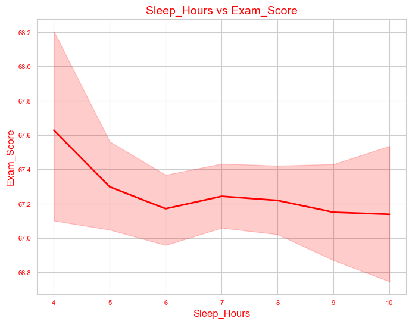

```python
#Visualization 5
#Line plot
plt.figure(figsize=(8,6))
sns.lineplot(x="Sleep_Hours",y="Exam_Score",data=df,color="red",linewidth=2)
plt.title("Sleep_Hours vs Exam_Score",color="red",fontsize=14)
plt.xlabel("Sleep_Hours",color="red",fontsize=12)
plt.ylabel("Exam_Score",color="red",fontsize=12)
plt.xticks(color="red",fontsize=8)
plt.yticks(color="red",fontsize=8)
plt.show()
```

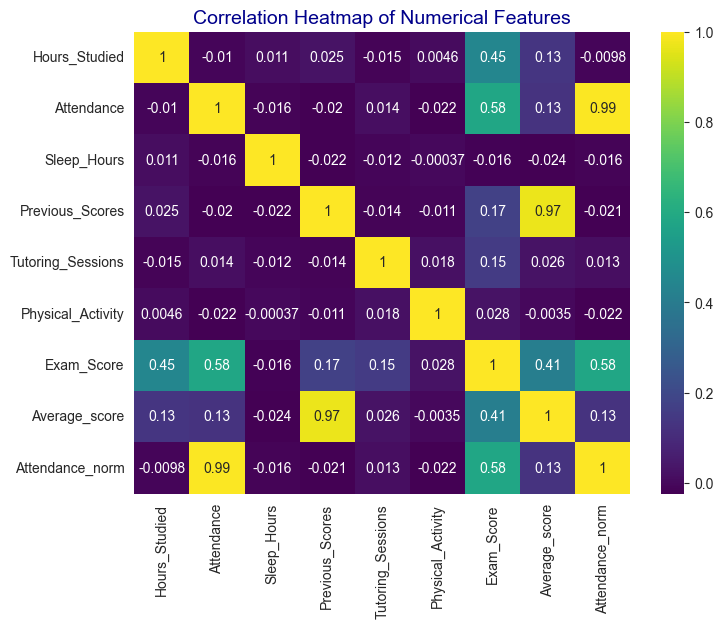

```python
#Visualization 6
#Multivariate analysis
#Heatmap
plt.figure(figsize=(8,6))
#calculating correlation between numerical columns ,showing values in each column and choosing the color style
sns.heatmap(df.corr(numeric_only=True), annot=True, cmap="viridis",linecolor="black")
plt.title("Correlation Heatmap of Numerical Features",color="darkblue",fontsize=14)
plt.show()
```

The correlation heatmap indicates how the numerical values are related .The value ranges from -1 to 1,1 indicates both increases together and -1 indicates inverse relationship and 0 means no linear relationship

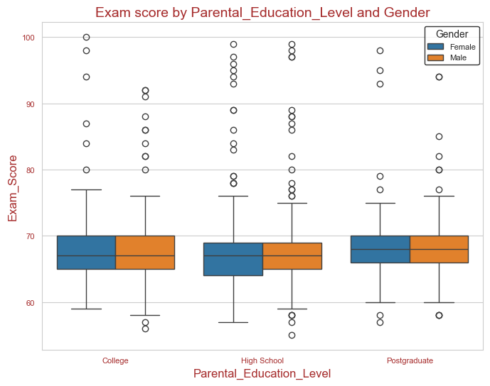

```python
#Visualization 7
#Boxplot
plt.figure(figsize=(8,6))
sns.boxplot(x="Parental_Education_Level",y="Exam_Score",hue="Gender",data=df,)
plt.title("Exam score by Parental_Education_Level and Gender",color="brown",fontsize=14)
plt.xlabel("Parental_Education_Level",color="brown",fontsize=12)
plt.ylabel("Exam_Score",color="brown",fontsize=12)
plt.xticks(color="brown",fontsize=8)
plt.yticks(color="brown",fontsize=8)
#showing legend on the plot
plt.legend(title="Gender",title_fontsize=10, fontsize=8,loc="upper right",frameon=True,edgecolor="black")
plt.show()
```

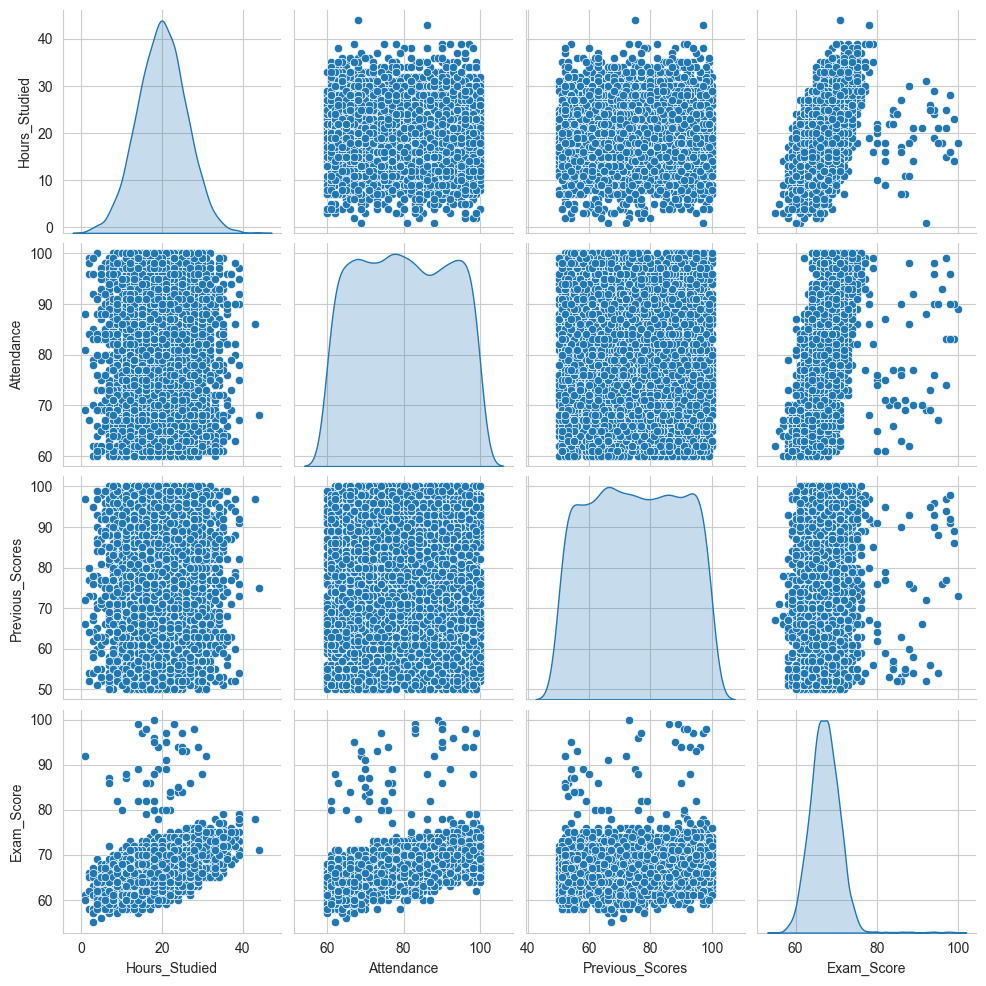

```python
#Visualization 8
#Pairplot
plt.figure(figsize=(10,8))
sns.pairplot(df[["Hours_Studied","Attendance","Previous_Scores","Exam_Score"]],kind="scatter",diag_kind="kde")
plt.xticks(color="blue",fontsize=8)
plt.yticks(color="blue",fontsize=8)
plt.show()
```

The above pairplot visualize the relationship between Hours_Studied,Attendance,Previous_Scores and Exam_Score

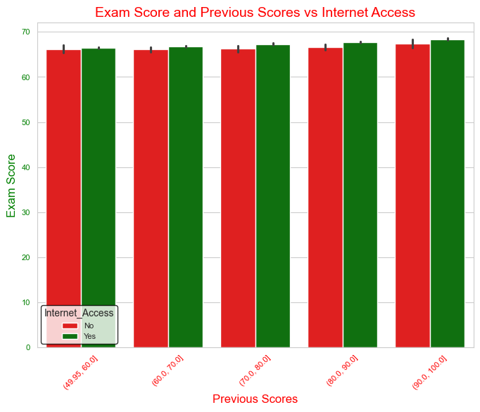

```python
#Visualization 9
#Barplot
plt.figure(figsize=(8,6))
df["Previous_Scores_bin"] = pd.cut(df['Previous_Scores'], bins=5)
sns.barplot(x="Previous_Scores_bin",y="Exam_Score",hue="Internet_Access",data=df,palette={"Yes":"green", "No":"red"})
plt.title("Exam Score and Previous Scores vs Internet Access",color="red",fontsize=14)
plt.xlabel("Previous Scores",color="red",fontsize=12)
plt.ylabel("Exam Score",color="green",fontsize=12)
plt.xticks(color="red",fontsize=8,rotation=45)
plt.yticks(color="green",fontsize=8)
plt.legend(title="Internet_Access",title_fontsize=10, fontsize=8,loc="lower left",frameon=True,edgecolor="black")
plt.show()
```

The Bargraph-Exam Score and Previous Scores vs Internet Access Shows that the students with Internet access have scored high marks than others.That implies accessing internet for studies is helpful for scoring marks according to this dataset.

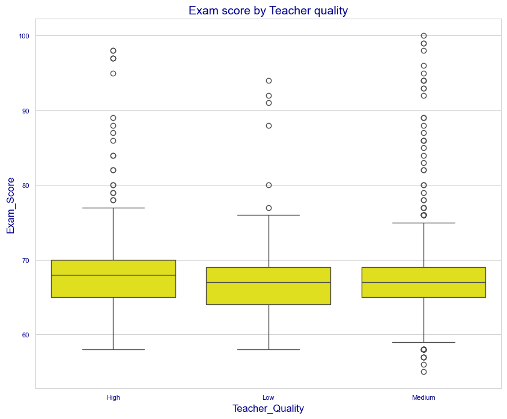

```python
#Visualization 10
#Boxplot
plt.figure(figsize=(10,8))
sns.boxplot(x="Teacher_Quality", y="Exam_Score", data=df,color="yellow")
plt.title("Exam score by Teacher quality",color="darkblue",fontsize=14)
plt.xlabel("Teacher_Quality",color="darkblue",fontsize=12)
plt.ylabel("Exam_Score",color="darkblue",fontsize=12)
plt.xticks(color="darkblue",fontsize=8)
plt.yticks(color="darkblue",fontsize=8)
plt.show()
```

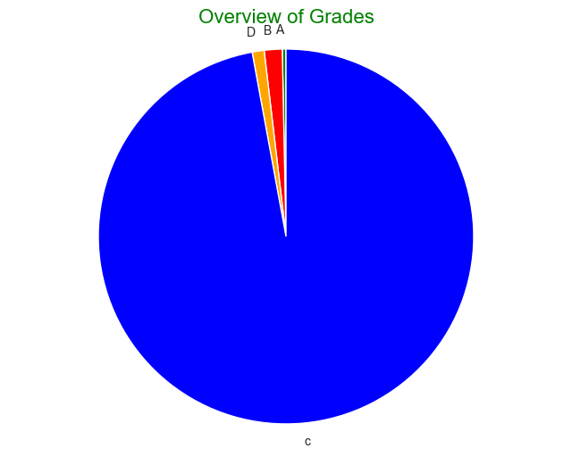

```python
#Visualization 11
#Piechart
#counting how many times each grade occurs
grade_count=df["Grade"].value_counts().sort_index()
plt.figure(figsize=(8,6))
plt.pie(grade_count,labels=grade_count.index,colors=["green","red","orange","blue","yellow"],startangle=90)
plt.axis("equal")
plt.title("Overview of Grades", fontsize=16, color="green")
plt.show()
```

The piechart-Grades shows that the majory of students achieve the C grade and only a few students shows their excellence in achieving A grade.This give an insight that various student-related academic, lifestyle, and socio-enconmic factores influence the efficiency to study in one way or in another way